# Lab: GORIC(A)

This lab material consists of multiple exercises regarding (informative) hypothesis evaluation using the GORIC(A).

## Exercise 1: NHT and GORIC (ANOVA)

### Data

All sub-exercises will be applied to the same data set: a simulated data set based on the Sesame Street data (Stevens, 1996), which is included as the dataset ‘sesamsim’ in the bain package. Thus, upon installing and loading the bain package, the sesamsim data set is automatically imported.

```r
# Install and load packages
#
# Install and load the bain library because it contains the data 'sesamesim'
if (!require("bain")) install.packages("bain") # install this package first (once)
library(bain) # for the data 'sesamesim' and for the function bain
#
if (!require("restriktor")) install.packages("restriktor") # install this package first (once)
library(restriktor) # for the function goric
# If you want to use restriktor from github:
#if (!require("devtools")) install.packages("devtools")
#library(devtools)
#install_github("LeonardV/restriktor")
#library(restriktor) # for goric function
#
if (!require("psych")) install.packages("psych") # install this package first (once)
library(psych) # for the function describeBy

# load the data set
data(sesamesim)
```

Since the exercises concern the effect of the children’s background on its increase in knowledge of numbers after watching Sesame street for one year, some data wrangling is required first. That is, a change score variable (i.e., the dependent variable) needs to be created, capturing the difference in knowledge after one year. To create the dependent variable, the children’s knowledge of numbers at baseline (prenumb) is subtracted from its knowledge of number after watching Sesame street for one year (postnumb):

```r
# create change score variable
sesamesim$post_pre <- sesamesim$postnumb - sesamesim$prenumb
```

In addition to the dependent variable, the grouping variable (site) needs to be transformed into a factor. The variable represents the background of a child and consists of 5 categories:

- disadvantaged inner city,
- advantaged suburban,
- advantaged rural,
- disadvantaged rural,
- disadvantaged Spanish speaking.

```r
# convert 'site' into a factor
sesamesim$site <- factor(sesamesim$site)
```

### Hypotheses

Assume that a group of researchers has come up with the following expectations:  
A. Children from a suburban advantaged background improve more than children from a rural one.  
B. Children from an advantaged background improve more than children from a disadvantaged background (for both 1. rural and 2. suburban).

More precisely:  
- A. In the advantaged suburban area (Group 2), the difference in knowledge of numbers is larger than in the advantaged rural area (Group 3):  
$\mu_2 > \mu_3$.  
- B1. In the advantaged rural area (Group 3), the difference in knowledge of numbers is larger than in the disadvantaged rural area (Group 4):  
$\mu_3 > \mu_4$.  
- B2. In the advantaged suburban region (Group 2), the difference in knowledge of numbers is larger than in the disadvantaged inner city (Group 1) and disadvantaged Spanish speaking area (Group 5):  
$\mu_2 > (\mu_1, \mu_5)$.

The researchers want to evaluate the expectations simultaneously, that is, they want to evaluate the following theory-based hypothesis:
$$H_1: \mu_2 > \mu_3 > \mu_4, \ \mu_2
> (\mu_1, \mu_5),$$
that is,
$$H_1:
\mu_2 > \mu_3 > \mu_4, \ \mu_2 > \mu_1, \ \mu_2 >
\mu_5.$$

The goal of this exercise is to evaluate this hypothesis using a one-way ANOVA with `site` as the grouping variable and the newly created change score variable `post_pre` as the dependent variable.

### Exercise 1a: Classical Null Hypothesis Testing (NHT)

In this exercise, evaluate the aforementioned hypothesis using classical null hypothesis testing.

**Click to show answers**

```r
# Optional: Check descriptive statistics
head(sesamesim) # Look at first (6) rows of the data
```

```
##   sex site setting viewenc age peabody prenumb postnumb funumb Bb Bl Bf Bn Br
## 1   1    1       1       0  36      48      30       34      0 10 16  3 18  7
## 2   1    3       1       1  61      28      24       31      0  8  7  2  7  7
## 3   1    4       1       0  44      54      10       19      1 21  4 11 21  9
## 4   1    3       1       1  40      20       3        3      2 16 21  8 20  8
## 5   1    1       1       0  43      43      19       25      5 14 13  8  1 11
## 6   1    1       2       0  55      30      24       26      6 21  8 13 23 13
##   Bc Ab Al Af An Ar Ac post_pre
## 1  8 22 18 11 27  9 13        4
## 2  4 14  2  9 14 10  9        7
## 3  9 34 36 22 17 11 13        9
## 4  5 26 28 17 32 15 18        0
## 5 10 22  7 10 10 10  9        6
## 6 16 28 37 15 41 14 21        2
```

```r
describeBy(sesamesim$post_pre, sesamesim$site, mat=TRUE) # obtain descriptives by group
```

```
##     item group1 vars  n      mean        sd median   trimmed     mad min max
## X11    1      1    1 60  5.783333  8.328207    5.0  5.770833  7.4130 -17  30
## X12    2      2    1 55 12.636364 11.005661   12.0 12.911111 10.3782 -24  32
## X13    3      3    1 64  8.718750  7.818311    9.5  8.788462  6.6717  -8  29
## X14    4      4    1 43  6.883721 10.270645    7.0  7.371429 10.3782 -21  23
## X15    5      5    1 18 10.555556  8.318811   11.0 11.062500  5.9304 -11  24
##     range        skew    kurtosis        se
## X11    47  0.10322321  0.36054880 1.0751670
## X12    56 -0.44957553  0.59529385 1.4840031
## X13    37 -0.06399545 -0.13668115 0.9772889
## X14    44 -0.42723461 -0.03212565 1.5662587
## X15    35 -0.70156486  0.31385289 1.9607625
```

```r
# Run a one-way ANOVA including NHT
lm_fit_sesam <- lm(post_pre~site-1, data=sesamesim)
summary(lm_fit_sesam)
```

```
##
## Call:
## lm(formula = post_pre ~ site - 1, data = sesamesim)
##
## Residuals:
##     Min      1Q  Median      3Q     Max
## -36.636  -5.783   0.281   6.281  24.217
##
## Coefficients:
##       Estimate Std. Error t value Pr(>|t|)
## site1    5.783      1.194   4.845 2.30e-06 ***
## site2   12.636      1.247  10.135  < 2e-16 ***
## site3    8.719      1.156   7.544 9.96e-13 ***
## site4    6.884      1.410   4.882 1.94e-06 ***
## site5   10.556      2.179   4.843 2.32e-06 ***
## ---
## Signif. codes:  0 '***' 0.001 '**' 0.01 '*' 0.05 '.' 0.1 ' ' 1
##
## Residual standard error: 9.246 on 235 degrees of freedom
## Multiple R-squared:  0.4951, Adjusted R-squared:  0.4843
## F-statistic: 46.08 on 5 and 235 DF,  p-value: < 2.2e-16
```

Note that the information given in the output is quiet limited.

We can see that the increase in knowledge of numbers for each of the five groups of children is significantly different from 0.

The hypothesis that all means are zero is rejected as well (F(5,235) = 46.08, p = 2.2e-16 < .001).

Conclusion: Except for inspecting the size of the group means, we cannot infer any conclusions about the ordering of the group means, let alone, the support for $H_1$.

### Exercise 1b: The GORIC

In this exercise, evaluate the aforementioned theory-based hypothesis using the GORIC (or better: the ratio of GORIC weights).

**Click to show which steps are needed**

- Read the data; e.g., use read.table().
- Create factor(s); e.g., use factor().
- Inspect data; e.g., use describeBy().
- Estimate linear model; use lm().
- Specify informative hypothesis/-es  
  (which should be known before seeing the data).
- Apply GORIC; use goric() from restriktor package.
- Interpret output  
  (possibly using `Guidelines_output_GORIC.html’ from https://github.com/rebeccakuiper/Tutorials).

**Click to show notes on specifying hypotheses for goric()**

- It is possible to use the following operators: `>`, `<`, `=`, `==`,`<=`or`>=` within the `goric()` function.
  - `==` operator is interpreted in the same fashion as the `=`, meaning an equality.
  - `<=` and `>=` operators are the same as `<` and `>`, respectively, denoting inequality constraints (i.e., smaller and larger than, respectively).
- The `goric()` function can deal with:
  - pairwise restrictions (e.g., “beta1 > beta2; beta2 < beta3”); one can also use a “&” or “,” to separate the restrictions within one hypothesis.
  - combined restrictions (e.g., “beta1 > beta2 < beta3”)
- One can use ‘abs()’ in case one wants to specify an absolute strength/effect (e.g., abs(beta1) > abs(beta2); abs(beta2) > abs(beta3)).

Remark:  
* In a paper, hypotheses are specified in terms of population model parameters (often expressed as Greek letters).  
* In R, hypotheses are specified in terms of  
- the names of variables to which the parameters of interest belong to and/or  
- the assigned labels of the parameters of interest.

**Click to show answers**

```r
# Specify the hypothesis of interest
H1_sesam <- 'site2 > site3 > site4;
             site2 > (site1, site5)'
# or:
#H1_sesam <- 'site2 > site3 > site4;
#             site2 > site1; site2 > site5'
# or:
#H1_sesam <- 'site2 > site3 > site4 &
#             site2 > site1 & site2 > site5'
#
# vs its complement (default in case of one hypothesis)

# Run GORIC
set.seed(123)
goric_sesam <- goric(lm_fit_sesam,
                     hypotheses = list(H1_sesam = H1_sesam))
goric_sesam
```

```
## restriktor (0.6-15): generalized order-restricted information criterion:
##
## Results:
##         model    loglik  penalty     goric  loglik.weights  penalty.weights
## 1    H1_sesam  -871.830    4.273  1752.205           0.587            0.794
## 2  complement  -872.180    5.623  1755.607           0.413            0.206
##    goric.weights
## 1          0.846
## 2          0.154
##
## Conclusion:
## The order-restricted hypothesis 'H1_sesam' has 5.48 times more support than its complement.
```

```r
#summary(goric_sesam)
```

The GORIC provides evidence for our hypothesis: The ratio of GORIC weights indicates that there is 5.5 $>1$ more support for hypothesis $H_{1}$ than for its complement (i.e., all other possible orderings/theories).

Additionally, the loglik values for $H_{1}$ and its complement seem to differ. Hence, this support does probably not reflect support for their boundary (i.e., having at least one equality) but for $H_{1}$ itself.  
More information can be found on the github repository https://github.com/rebeccakuiper/Tutorials:  
- ‘Guidelines_output_GORIC’ (html or pdf)  
- ‘Decision tree - Interpretation.pdf’

On average, the data thus supports our hypothesis that children from a suburban advantaged background improve more than children from a rural one and that children from an advantaged background improve more than children from a disadvantaged background (for both rural and suburban).

## Exercise 2: Benchmarks

The GORIC(A) weights nicely quantify the support for your hypothesis of interest. Even though it is easily interpreted, you may have noticed that sometimes it is hard to label the support. In a way, we do not want to label it, because cut-off points can invoke questionable research practices, but benchmarks do ease the interpretation even further. Let us, therefore, inspect benchmarks for the GORIC(A). The R package `restriktor` contains a `benchmark` function.

The `benchmark` function renders benchmarks that are study-specific, that is, if another hypothesis and/or other (numbers of) parameters and/or another statistical model is used, the benchmark values change.  
The benchmark function uses a pre-specified null population, but one can also specify one or more other null population.

The benchmark function gives the distribution of ratios of GORIC(A) weights (and more) under one ore more null populations and under the population based on the sample. The benchmarks under the null then reflect how extreme your finding is when that null population would be true.  
More information can be found on the github repository https://github.com/rebeccakuiper/Tutorials:  
- ‘Guidelines_GORIC-benchmarks’ (html or pdf) and  
- ‘Hands-on_123_Extra_Benchmarks_ANOVA_restriktor.R’ (in the Hands-on files folder).  
If needed: ’_README.md’ describes how to download the files from github.

Exercise: When looking at the ratio of GORIC weights from Exercise 1, how would you label that (using the benchmark function)?

**Click to see benchmark code**

```r
## If ANOVA model:
#benchmarks_means <- benchmark(goric_object, model_type = "means", ncpus = 8)
#benchmarks_means
#plot(benchmarks_means)
## Use 'pop_es' to specify own null population(s).
#
## If ANOVA or other model:
benchmarks_asymp <- benchmark(goric_object, ncpus = 8)
# 'model_type = "asymp"', the default
benchmarks_asymp
plot(benchmarks_asymp)
# Use 'pop_est' to specify own null population(s).
#
#
# print() options:
# output_type = c("rgw", "gw", "rlw", "ld", "all")
# hypo_rate_threshold = <number>
#
# plot() options:
# output_type = c("rgw", "gw", "rlw", "ld")
# percentiles = NULL
# x_lim = c(<min>, <max>)
# log_scale = FALSE/TRUE
#
#
# I will use the default benchmarks code.
```

**Click to show answers**

```r
#benchmarks_sesam <- benchmark(goric_sesam, model_type = "means", ncpus = 8)
benchmarks_sesam <- benchmark(goric_sesam, ncpus = 8)
```

```
## Calculating asymptotic benchmark for population estimates = No-effect
```

```
## Calculating asymptotic benchmark for population estimates = Observed
```

```r
#
#benchmarks_sesam # use in R file
print(benchmarks_sesam, color = FALSE) # use in Rmd file
```

```
##
## Benchmark Results
## ----------------------------------------------------------------------
## Preferred Hypothesis: H1_sesam
## Error probability Preferred Hypothesis vs. Complement: 0.155
## Sample Size: 240
## Number of Parameters: 5
## Population Estimates (PE):
##            site1   site2  site3  site4   site5
## No-effect  8.692   8.692  8.692  8.692   8.692
## Observed   5.783  12.636  8.719  6.884  10.556
##
##
## =========================================================================================
## Benchmark: Percentiles of Ratio-of-GORICA-weights for the Preferred Hypothesis 'H1_sesam'
## -----------------------------------------------------------------------------------------
## Population estimates = No-effect
##                         Sample 5%    35%   50%   65%   95%
## H1_sesam vs. complement 5.442  0.190 1.588 2.329 3.033 3.921
##
## Population estimates = Observed
##                         Sample 5%    35%   50%   65%   95%    hypothesis_rate
## H1_sesam vs. complement 5.442  2.183 3.861 4.076 4.744 14.602 0.988
```

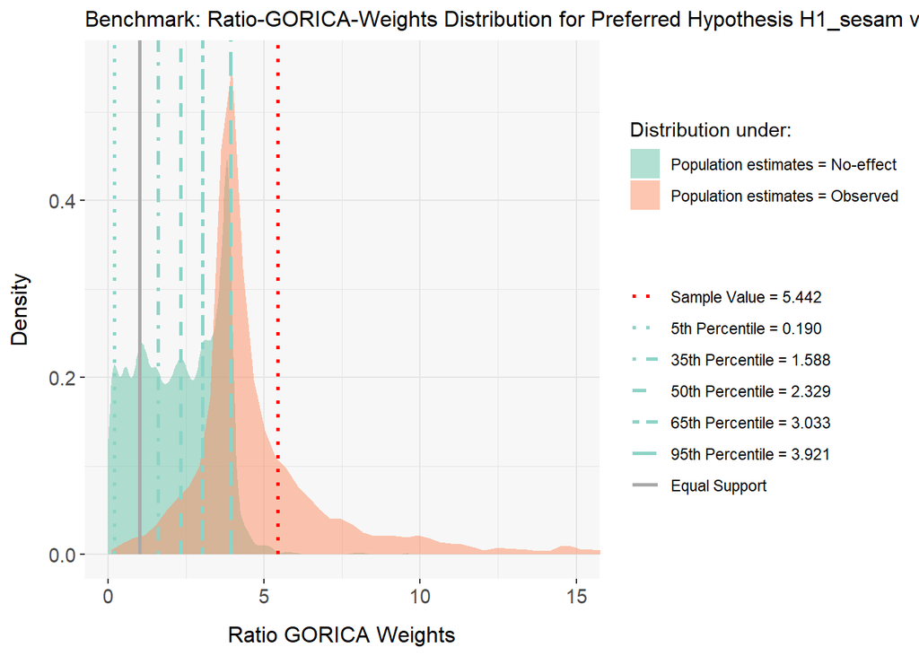

```r
#
plot(benchmarks_sesam, x_lim = c(0, 15))
```

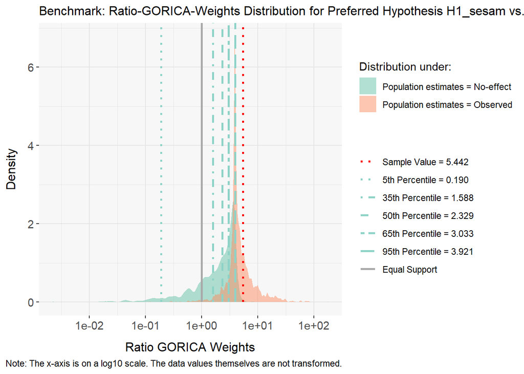

```r
plot(benchmarks_sesam, log_scale = T)
```

One can see, from ‘Error probability Preferred Hypothesis vs. complement’, that there is a 15.5% change that ‘H1_sesam’ is not the correct hypothesis.

From the output, we can also see that our finding is very extreme under the null, since our sample value is higher than the 95th percentile under the null. Hence, there is tremendous support for ‘H1_sesam’ (cf. ‘Guidelines_GORIC-benchmarks’).

# Exercise 3: GORICA (latent regression)

In this exercise, we will inspect a latent regression model; using the ‘sesamesim’ data from Exercise 1.

The exercise concerns the effect of watching one year of the tv-series “Sesame Street” on the knowledge of numbers of N = 240 children aged between 34 and 69 months. Several variables have been measured before and after watching Sesame Street for one year: Knowledge of numbers before (Bn) and after (An) watching, and analogously, knowledge of body parts (Bb and Ab), letters (Bl and Al), forms (Bf and Af), relationships (Br and Ar), and classifications (Bc and Ac). The score ranges on these variables ranges from ‘1 to 20’ to ’1 to 70‘. In the exercises, we will use these variables as well as the following ones: biological age in months (age; score range: 34 to 69) and the Peabody test measuring the mental age of children (peabody; score range: 15 to 89).

In this exercise, we will inspect the model, in which the A(fter) measurements (i.e., Ab, Al, Af, An, Ar, and Ac) load on the factor A, and the B(efore) measurements load on the factor B. In addition, A is regressed on B, age, and peabody, to investigate whether children’s knowledge after watching Sesame Street for a year is predicted by their knowledge one year before, as well as by their biological and mental age, which have a correlation of

```r
cor(sesamesim$peabody, sesamesim$age)
```

```
## [1] 0.2396424
```

($\approx .24$); so, there is no multicollinearity.

The latent regression model is specified and run with the lavaan package as follows:

```r
# install this package first (once)
if (!require("lavaan")) install.packages("lavaan")
# Load
library(lavaan)
# Needed to run a SEM model, like the latent regression model.

#Specification of the latent regression model in lavaan
model <- '
    A =~ Ab + Al + Af + An + Ar + Ac
    B =~ Bb + Bl + Bf + Bn + Br + Bc
    A ~ AB*B + AAge*age + APeabody*peabody'
# Fit the model
fit <- sem(model, data = sesamesim, std.lv = TRUE)
```

It is a good practice to draw the SEM model you plan to estimate:

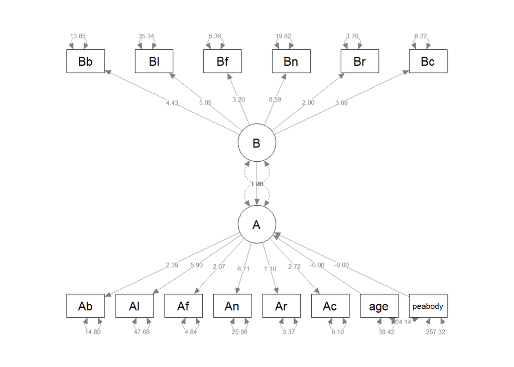

```r
# install this package first (once)
if (!require("semPlot")) install.packages("semPlot")
library(semPlot)

# plot
semPaths(fit, "par", weighted = FALSE, nCharNodes = 7, shapeMan = "rectangle",
         sizeMan = 8, sizeMan2 = 5)
```

Come up with one or more informative, theory-based hypotheses and a failsafe hypothesis (this could be about the factor loadings and/or the regression parameters).

**Click to show information on the hypotheses used in the answers**

In the solution, we evaluate three theory-based hypotheses (H1-H3) on standardized regression coefficients. Since these three do not cover all the possible theories, we include the unconstrained as failsafe.

- **H1** specifies that a larger score on B corresponds to a larger score on A (i.e., a positive relation between B and A) and that age and peabody do not predict A.
- **H2** specifies that the positive relation between B and A is stronger than the positive relation between peabody and A and that age cannot be used to predict A.
- **H3** specifies that the predictive power of B is larger than that of peabody, which, in turn, is larger than that of age which in turn is positive.

Notably, only in case all these hypotheses are of interest, these should all be included in the set; especially if there is overlap like here (see the article: https://doi-org.proxy.library.uu.nl/10.1080/10705511.2020.1836967 and/or ‘Guidelines_output_GORIC.html’ on https://github.com/rebeccakuiper/Tutorials for more information).

Evaluate the hypotheses with the GORICA: Interpret the output. What are your conclusions?

**Click to show answers**

**GORICA**

In our hypotheses (as in many hypotheses not addressing mean values), we need standardized parameters for a meaningful and fair comparison. Because we have more than one hypothesis, we need to use the unconstrained as failsafe, which is the default option in goric(). The R code for using the GORICA to evaluate our competing hypotheses is as follows:

```r
#Specification of the hypothesis of interest
H1 <- "AB > APeabody = AAge = 0"
H2 <- "AB > APeabody > AAge = 0"
H3 <- "AB > APeabody > AAge > 0"

# GORICA
set.seed(100)
results <- goric(fit, hypotheses = list(H1 = H1, H2 = H2, H3 = H3),
                 #type = "gorica", # default if lavaan object
                 standardized = TRUE)
results
```

```
## restriktor (0.6-15): generalized order-restricted information criterion approximation:
##
## Results:
##            model  loglik  penalty   gorica  loglik.weights  penalty.weights
## 1             H1   6.836    0.500  -12.672           0.246            0.379
## 2             H2   6.836    0.687  -12.297           0.246            0.315
## 3             H3   6.836    0.822  -12.028           0.246            0.275
## 4  unconstrained   6.894    3.000   -7.789           0.261            0.031
##    gorica.weights  gorica.weights_without_unc
## 1           0.379                       0.392
## 2           0.314                       0.325
## 3           0.274                       0.284
## 4           0.033
```

```
## ---
## Note: Hypotheses 'H1' and 'H2' and 'H3' have equal log-likelihood values. This indicates that they overlap and that the ratio of their GORIC(A) weights reached its maximum. If of interest, we recommend evaluating the overlap versus its complement. Run vignette("Guidelines_GORIC_output") in your c…
```

```
##
## Conclusion:
## - The order-restricted hypothesis 'H1' is the best in the set, as it has the highest GORIC(A) weight.
## - Since 'H1' has a higher GORIC(A) weight than the unconstrained hypothesis, it is not considered weak. We can now inspect the relative support for 'H1' against the other order-restricted hypotheses:
##   * 'H1' is 1.206 times more supported than 'H2' (This relative support reached its maximum, see Note).
##   * 'H1' is 1.380 times more supported than 'H3' (This relative support reached its maximum, see Note).
```

```r
#summary(results)
```

Note: In case of equal log-likelihood (loglik) values (i.e., ratio of loglik weights of 1), the ratio of GORICA weights are solely based on the difference in penalty values. See the article (https://doi-org.proxy.library.uu.nl/10.1080/10705511.2020.1836967) or the guidelines (‘Guidelines_output_GORIC.html’ on https://github.com/rebeccakuiper/Tutorials) for more information.

**Possible conclusions**

- Since (at least one of) the theory-based/informative hypotheses obtains more support than the unconstrained, we can meaningfully compare the theory-based/informative hypotheses. That is, we do not select the best from a set of weak hypotheses.
- Since the hypotheses overlap and the most restricted one (H1) receives the most support (and is not weak), H1 is the preferred hypothesis.
- Because the support for the other hypotheses also contain support for H1, one could also compare H1 to its complement, see below. This shows convincing support for H1.
- Thus, there is support for the hypothesis that a larger score on B corresponds to a larger score on A (i.e., a positive effect) and that age and peabody do not predict A. Based on the evaluation below, this hypothesis is approximately 7 times more likely than its complement containing all competing hypotheses.

**Extra: H1 vs its complement**

Since the hypotheses are nested, the hypotheses share support. Therefore, we also examine the best of these (i.e., H1) against its complement:

```r
set.seed(100)
results_c <- goric(fit, hypotheses = list(H1 = H1),
                   #comparison = "complement", # default if one hypothesis
                   #type = "gorica", # default if lavaan object
                   standardized = TRUE)
#summary(results_c)
results_c
```

```
## restriktor (0.6-15): generalized order-restricted information criterion approximation:
##
## Results:
##         model  loglik  penalty   gorica  loglik.weights  penalty.weights
## 1          H1   6.836    0.500  -12.672           0.485            0.881
## 2  complement   6.894    2.500   -8.789           0.515            0.119
##    gorica.weights
## 1           0.874
## 2           0.126
##
## Conclusion:
## The order-restricted hypothesis 'H1' has 6.97 times more support than its complement.
```

The order-restricted hypothesis ‘H1’ has 6.97 times more support than its complement.

Note: The log-likelihood (loglik) weights seem to be quite close. This could then indicate that one or more of the inequality constraints can be replaced by (about-)equality constraints (leading to one or more boundary hypotheses). One could investigate with the benchmarks function, using ‘output_type = “rlw”’, whether the loglik weights indeed are close.  
*However*, in this case, there is already at least one equality (namely 2: “AB > APeabody = AAge = 0”). Thus, this hypothesis is a possible boundary hypothesis. Therefore, the (seemingly) close loglik weights can be due to that (so, there does not need to be another equality). You could check (using ‘output_type = “glw”’, which is the default) for multiple boundary hypotheses whether indeed the obtained ratio of GORICA weights fits the distribution based on this hypothesis better than the distributions of the other boundary hypotheses (here, “AB = APeabody = AAge = 0”).  
Notably, replacing the equality by an about-equality may solve the problem. Hence, whenever you are interested in an equality and you can specify a range of values not deemed meaningful, I would advise you to include that in your hypotheses (e.g. “AB > (APeabody, AAge), APeabody - AAge > -0.01, APeabody - AAge < 0.01”).  
For more information, see the guidelines (‘Guidelines_output_GORIC.html’) and/or the benchmark tutorial on https://github.com/rebeccakuiper/Tutorials.

**Click to show code for a sensitivity check**

**Sensitivity check**

Next, you find code to check the influence of the seed in calculating the penalty (PT), which turns out to be negligible.

```r
results$result[,3]
```

```
## [1] 0.5000000 0.6873956 0.8218584 3.0000000
```

```r
set.seed(100)
goric(fit, hypotheses = list(H1 = H1, H2 = H2, H3 = H3),
      standardized = TRUE)$result[,3]
```

```
## [1] 0.5000000 0.6873956 0.8218584 3.0000000
```

```r
set.seed(100100)
goric(fit, hypotheses = list(H1 = H1, H2 = H2, H3 = H3),
      standardized = TRUE)$result[,3]
```

```
## [1] 0.5000000 0.6873956 0.8218222 3.0000000
```

```r
set.seed(123456)
goric(fit, hypotheses = list(H1 = H1, H2 = H2, H3 = H3),
      standardized = TRUE)$result[,3]
```

```
## [1] 0.5000000 0.6873956 0.8218407 3.0000000
```

### Exercise 3 (Optional): Alternative input

Do the same evaluation as above, but now use the (standardized) estimates and their covariance matrix as input to the goric function (instead of the lavaan object). E.g., use:

```
`goric(est, VCOV = vcov,
       #type = "gorica" # default if est & VCOV
       #comparison = "complement" # default if one hypothesis
       hypotheses = list(H1))`
```

with `est` the (standardized) estimates and `vcov` their covariance matrix.

**Click to show answers**

Next, we will extract the standardized(!) estimates of interest and their covariance matrix from the lavaan object (labelled or unlabelled) and use that in the goric function.

Obtain standardized(!) estimates from lavaan object (labelled or unlabelled) via:

```r
# Extract standardized estimates of interest
est <- lavaan::standardizedsolution(fit)[13:15, 'est.std']
names(est) <- c("beta_AB", "beta_AAge", "beta_APeabody")
# These labels should be used in the hypothesis.

# Extract their covariance matrix
vcov <- lavInspect(fit, "vcov.std.all")[13:15, 13:15]
# Use this in the 'VCOV = ' command in goric (i.e., 'VCOV = vcov').
```

Now, use these when calculating the GORICA values and weights for the hypotheses of interest, via:

```r
# Specify hypotheses using labeling from above
H1 <- "beta_AB > beta_APeabody = beta_AAge = 0"
H2 <- "beta_AB > beta_APeabody > beta_AAge = 0"
H3 <- "beta_AB > beta_APeabody > beta_AAge > 0"

# GORICA
set.seed(100)
results_est <- goric(est, VCOV = vcov, hypotheses = list(H1, H2, H3))
#summary(results_est)
results_est
```

```
## restriktor (0.6-15): generalized order-restricted information criterion approximation:
##
## Results:
##            model  loglik  penalty   gorica  loglik.weights  penalty.weights
## 1             H1   6.836    0.500  -12.672           0.246            0.379
## 2             H2   6.836    0.687  -12.297           0.246            0.315
## 3             H3   6.836    0.822  -12.028           0.246            0.275
## 4  unconstrained   6.894    3.000   -7.789           0.261            0.031
##    gorica.weights  gorica.weights_without_unc
## 1           0.379                       0.392
## 2           0.314                       0.325
## 3           0.274                       0.284
## 4           0.033
```

```
## ---
## Note: Hypotheses 'H1' and 'H2' and 'H3' have equal log-likelihood values. This indicates that they overlap and that the ratio of their GORIC(A) weights reached its maximum. If of interest, we recommend evaluating the overlap versus its complement. Run vignette("Guidelines_GORIC_output") in your c…
```

```
##
## Conclusion:
## - The order-restricted hypothesis 'H1' is the best in the set, as it has the highest GORIC(A) weight.
## - Since 'H1' has a higher GORIC(A) weight than the unconstrained hypothesis, it is not considered weak. We can now inspect the relative support for 'H1' against the other order-restricted hypotheses:
##   * 'H1' is 1.206 times more supported than 'H2' (This relative support reached its maximum, see Note).
##   * 'H1' is 1.380 times more supported than 'H3' (This relative support reached its maximum, see Note).
```

The results are of course exactly the same and, consequently, the conclusions as well.

## Exercise 4 (Optional): The sky is the limit

You can try out evaluating informative, theory-based hypotheses using other data sets; for example, one or more from the subfolder ‘data’ on the github repository https://github.com/rebeccakuiper/Tutorials or perhaps from https://openpsychometrics.org.

You can also look into other types of models (e.g., SEM and (RI-)CLPM).  
Examples files for the GORIC(A) can be found on https://github.com/rebeccakuiper/Tutorials. In ’_README.md’, you can find an overview of the (example and tutorial) files.

You can of course, when available, also use your own data.